# My Rmd document

Juan Solorio

10 February, 2020

Starwars Logo

[figure not shown]

# Introduction

This is a test of RMarkdown using the starwars dataset in tidyverse. The dataset has 87 rows and 13 columns.

# Data Exploration

Here is are some plots of the data set:

Plots showing Height and Density by Mass of Genders

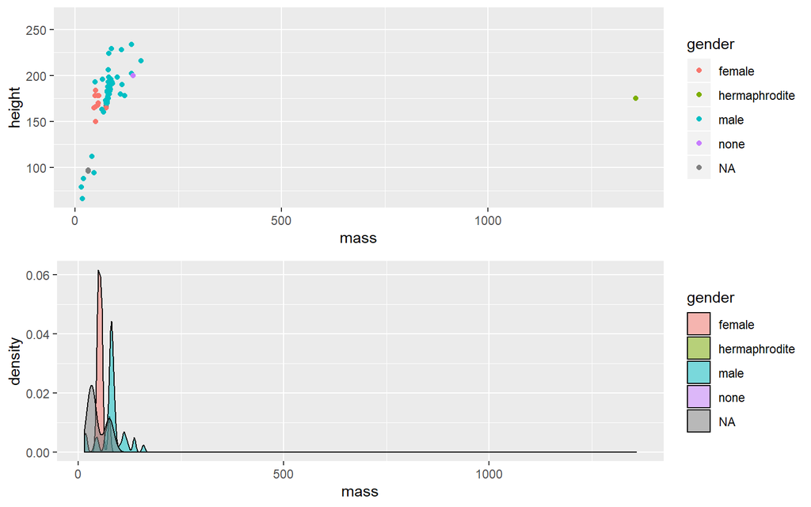

[output not shown]

```r
vizual_sct_den(starwars, mass, height, gender)
```

Now lets look at a table describing the dataset:

```
## The Starwars data set contains 87 rows and 13 columns
##
##             Columns have the following type and number of NAs
##    Column.Name Column.Type Number.NAs per.of.NAs
## 1         name   character          0          0
## 2       height     integer          6          7
## 3         mass      double         28         32
## 4   hair_color   character          5          6
## 5   skin_color   character          0          0
## 6    eye_color   character          0          0
## 7   birth_year      double         44         51
## 8       gender   character          3          3
## 9    homeworld   character         10         11
## 10     species   character          5          6
## 11       films        list          0          0
## 12    vehicles        list          0          0
## 13   starships        list          0          0
```

Let’s take a look at a subset of the dataset for human species:

Table of starwars data for Human species total mass by homeworlds

| homeworld | Total.Human.Species.Mass |
| --- | --- |
| Corellia | 157.0 |
| Bestine IV | 110.0 |
| Haruun Kal | 84.0 |
| Serenno | 80.0 |
| Bespin | 79.0 |
| Concord Dawn | 79.0 |
| Socorro | 79.0 |
| Kamino | 78.2 |
| Stewjon | 77.0 |

# Citations and More Data

There is more analysis in the article “Movienet: A Movie Multilayer Network Model using Visual and Textual Semantic Cues”. (Mourchid 2019).

Mourchid, Youssef. 2019. “Movienet: A Movie Multilayer Network Model Using Visual and Textual Semantic Cues.” *arXiv Preprint arXiv:1910.09368*.

“It’s a Trap: Emperor Palpatine’s Poison Pill” is another article with Star Wars analysis of economic repercusions. (Feinstein 2015).

Feinstein, Zachary. 2015. “It’s a Trap: Emperor Palpatine’s Poison Pill.” *arXiv Preprint arXiv:1511.09054*.